# Study NBI-1070770-1747 Cohort X PK Report

2022-07-28

Phase 1, Randomized, Placebo-Controlled, Double-Blind, Ascending Single-Dose and Multiple-Dose, and Food Effect Study to Evaluate the Safety, Tolerability, Pharmacokinetics, and Pharmacodynamics of NBI-1070770 in Healthy Subjects

This is the PK report for Study NBI-1070770-1747 Cohort X.

## PK Concentration

Mean concentration versus time profiles for NBI-1070770 are presented in linear scale:

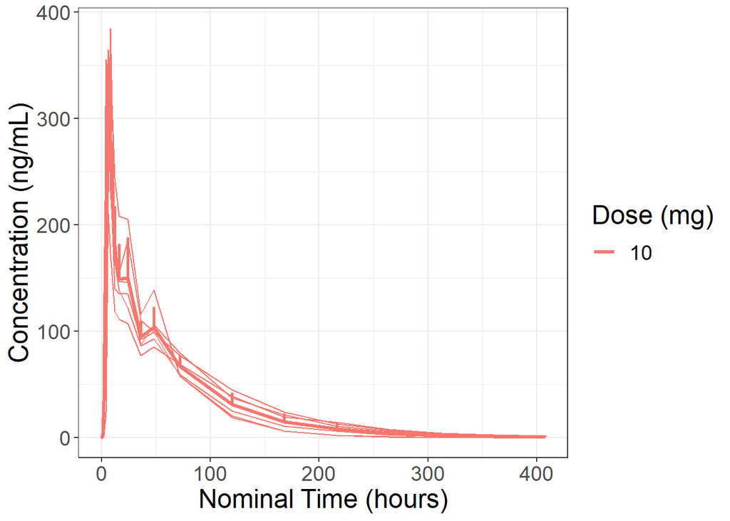

and log scale:

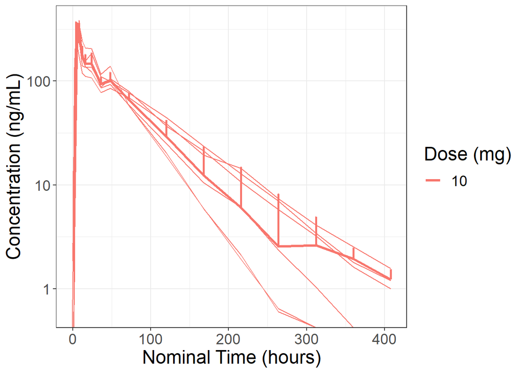

Mean (SD) are represented in thick line(s) by dose. Individual profile are represented in thin lines by dose.

Individual concentration versus time profiles for NBI-1070770 are presented in linear scale:

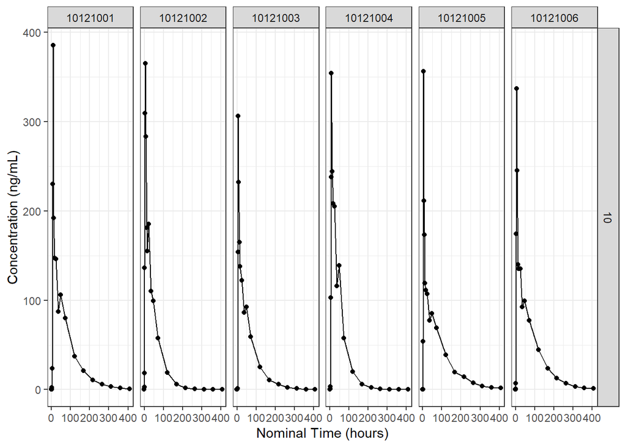

and log scale:

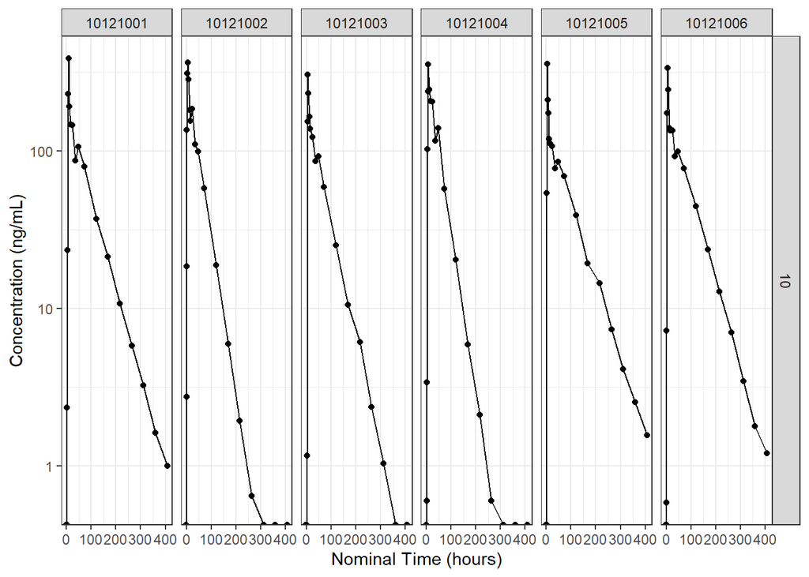

## PK Parameter

Summary of PK parameters by dose is presented as follows:

| Dose (mg) | Parameter | Mean | Stdev | Min | Median | Max | Gmean | Gcv% |
| --- | --- | --- | --- | --- | --- | --- | --- | --- |
| 10 | AUC%extrap (%) | 0.562 | 0.359 | 0.196 | 0.553 | 1.188 | 0.469 | 76.57 |
| 10 | AUCinf (ng*h/mL) | 12981.297 | 1285.058 | 11102.394 | 12994.164 | 14528.289 | 12927.364 | 10.07 |
| 10 | AUCtlast (ng*h/mL) | 12907.624 | 1269.496 | 11039.243 | 12903.991 | 14433.640 | 12854.688 | 10.01 |
| 10 | CL/F (L/h) | 4.698 | 0.477 | 4.157 | 4.649 | 5.431 | 4.679 | 10.05 |
| 10 | Cmax (ng/mL) | 350.500 | 26.853 | 306.000 | 355.000 | 385.000 | 349.617 | 7.85 |
| 10 | lambda_z (1/h) | 0.017 | 0.006 | 0.010 | 0.015 | 0.024 | 0.016 | 35.98 |
| 10 | t1/2 (h) | 46.223 | 15.569 | 29.206 | 47.488 | 68.880 | 43.992 | 35.98 |
| 10 | tlag (h) | 0.672 | 0.414 | 0.000 | 0.750 | 1.033 | 0.763 | 40.07 |
| 10 | tmax (h) | 6.361 | 1.500 | 4.000 | 6.083 | 8.000 | 6.201 | 25.88 |
| 10 | Vz/F (L) | 308.711 | 93.009 | 198.974 | 327.009 | 454.612 | 296.935 | 31.60 |

## Exposures and NOAEL

For all cohorts, dose increases will not exceed a 3.34-fold increase from the highest previously administered single dose and will not exceed the dose projected to achieve the mean steady-state maximum plasma concentration (Cmax) and area under the plasma concentration versus time curve (AUC) values associated with NOAEL in the male rats (most sensitive species) 28-day Good Laboratory Practices (GLP) toxicity studies (Cmax: 27,300 ng/mL; AUC: 121,000 ng×h/mL).

The fold-change against the NOAEL based on the mean Cmax for the current dose level is:

```r
  (27300-350.500)/350.500
```

```
## [1] 76.9
```

The fold-change against the NOAEL based on the mean AUCinf for the current dose level is:

```r
  (121000-12981.297)/12981.297
```

```
## [1] 8.32
```